# Assignment 5

Michael LaVallee

9/30/2019

#### 1 clean dataset

```r
library(tidyverse)
library(readxl)
c2015 = read_excel("C:/Users/student/Documents/Senior Year/Fall Semester/R Analytics/Data Set/c2015.xlsx")
```

```r
c2015 = c2015%>% mutate(TRAV_SP=sapply(strsplit(TRAV_SP,split = " ",fixed=TRUE),function(x)(x[1])),TRAV_SP=as.numeric(TRAV_SP))
c2015 = c2015 %>% filter_all(~! is.na(.))
c2015 = c2015 %>% filter_all(~!(.=='Unknown'))
c2015 = c2015 %>% filter_all(~!(.=='Unkno'))
c2015 = c2015 %>% filter_all(~!(.=='Not Rep'))
c2015 = c2015 %>% filter_all(~!(.=='Unknown (Police Reported)'))
c2015 = c2015 %>% filter_all(~!(.==str_detect(.,'Not Rep')))
c2015 = c2015 %>%filter_all(~!(.==str_detect(.,'Unknown ')))
c2015 = c2015 %>% filter_all(~!(.=='Not Reported'))
c2015 = c2015 %>% filter(SEAT_POS == 'Front Seat, Left Side')

c2015 = c2015%>% mutate(AGE = replace(AGE, AGE=='Less than 1', '0'),AGE=as.numeric(AGE))
```

#### 2 Use geom_point to plot AGE and TRAV_SP coloring by SEX

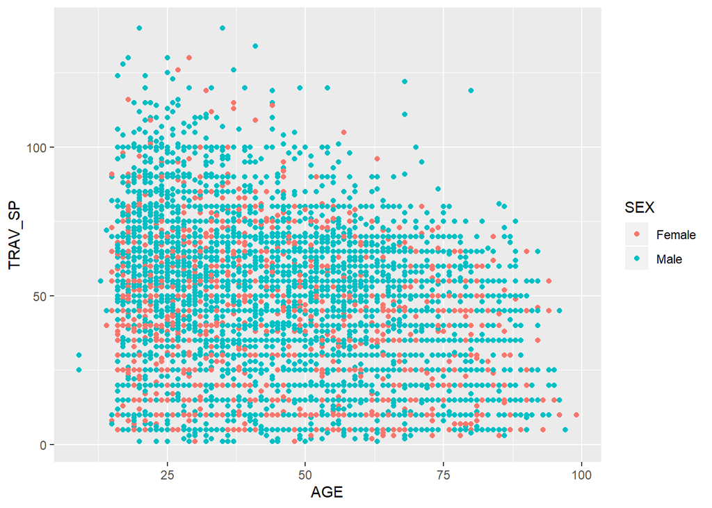

```r
ggplot(c2015, aes(AGE,TRAV_SP,color=SEX))+
geom_point()
```

#### 3 There is overplotting in 2. Overplotting is when many points are duplicated on the graph. Use geom_jitter instead of geom_point for 2. to avoid overplotting.

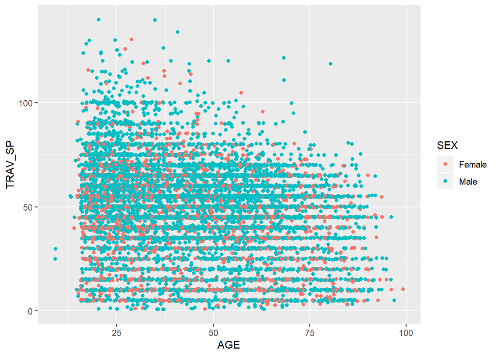

```r
ggplot(c2015, aes(AGE,TRAV_SP,color=SEX))+
geom_jitter()
```

#### 4 Plot histograms of AGE, TRAV_SP with bins = 50.

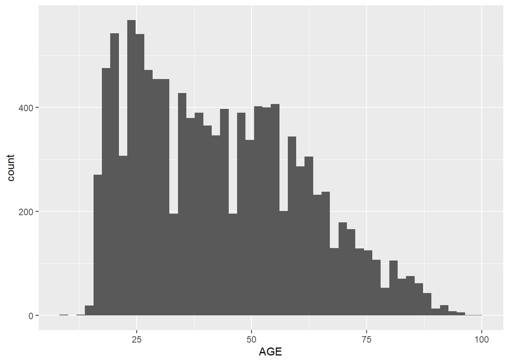

```r
ggplot(c2015, aes(AGE))+
geom_histogram(bins=50)
```

#### 4b

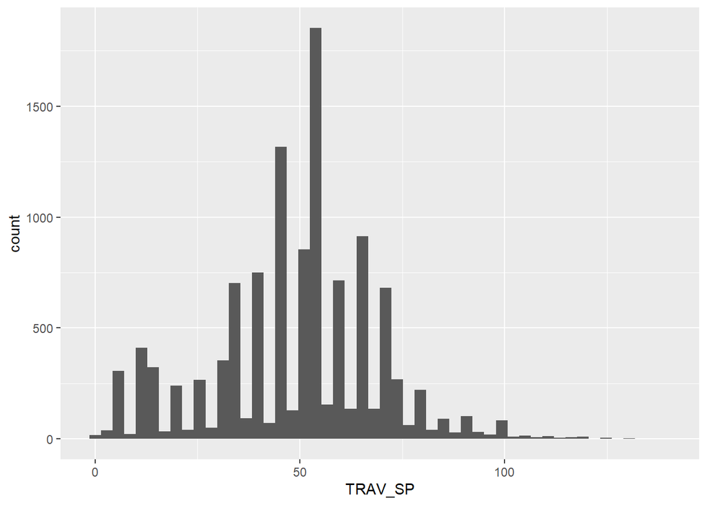

```r
ggplot(c2015, aes(TRAV_SP))+
geom_histogram(bins=50)
```

#### 5 Plot a histogram of AGE coloring (fill) by SEX.

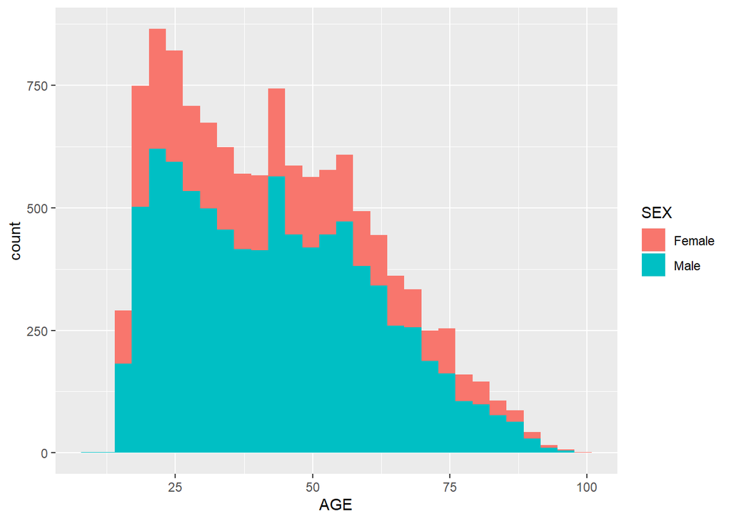

```r
ggplot(c2015,aes(x=AGE, fill=SEX) )+
  geom_histogram()
```

#### 6 Using geom_density to plot estimated densities of AGE colored by SEX.

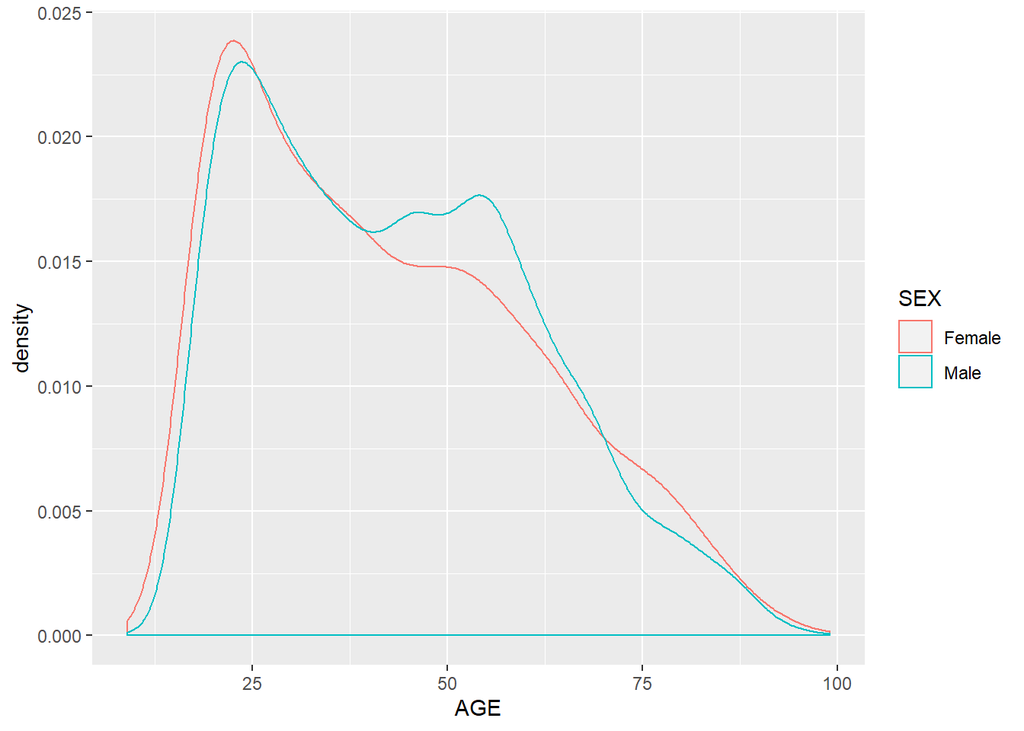

```r
ggplot(c2015,aes(AGE,color = SEX),)+
       geom_density()
```

#### 7 Plot estimated densities of TRAV_SP colored by INJ_SEV.

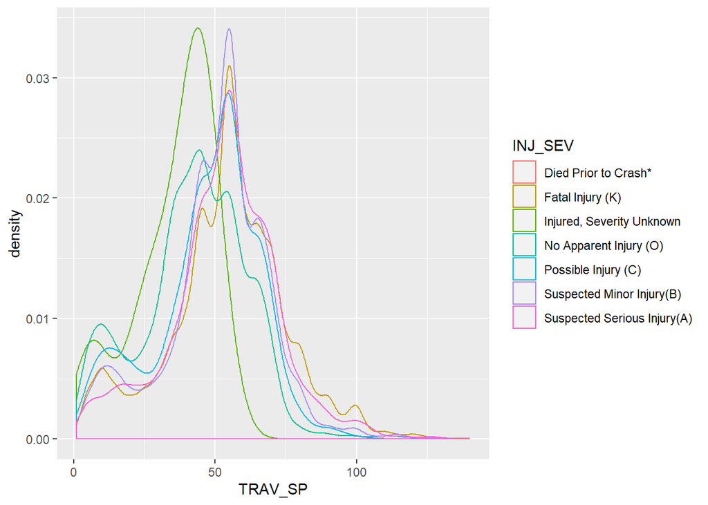

```r
ggplot(c2015,aes(TRAV_SP,color = INJ_SEV),)+
       geom_density()
```

#### 8 Plot estimated densities of TRAV_SP seperated (colored) by weekdays and weekends.

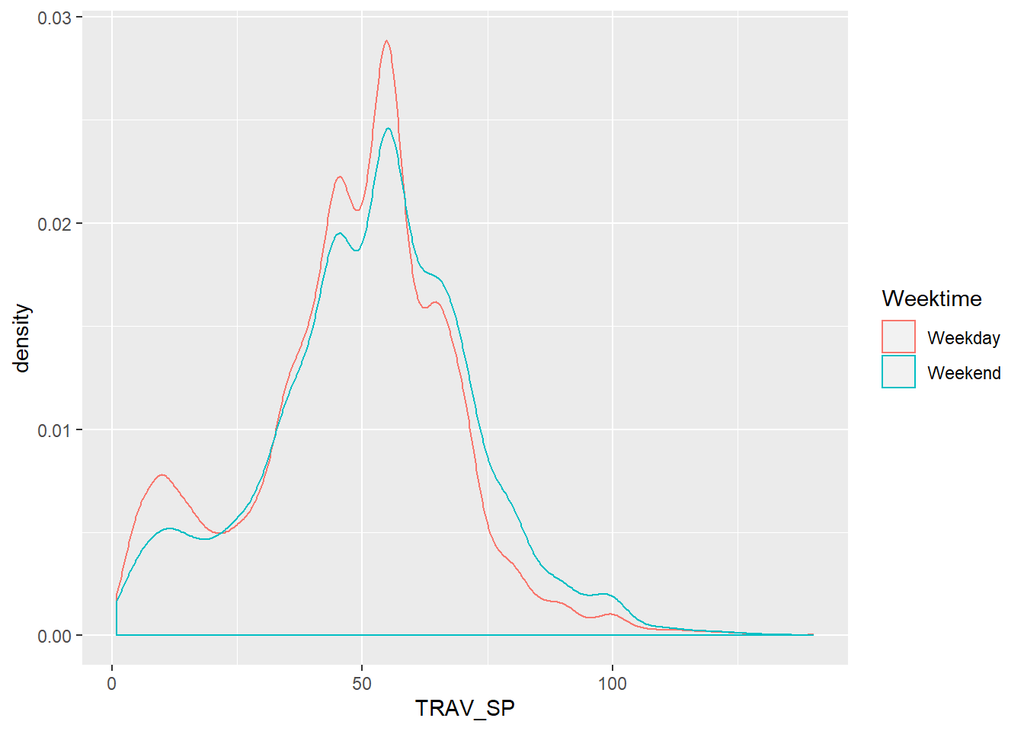

```r
c2015 <- c2015%>% mutate(Weektime = recode(DAY_WEEK,'Monday' = 'Weekday', 'Tuesday'='Weekday', 'Wednesday' = 'Weekday', 'Thursday' = 'Weekday', 'Friday' = 'Weekday', 'Saturday' = "Weekend", 'Sunday' = 'Weekend' ))

ggplot(c2015,aes(TRAV_SP,color=Weektime))+
  geom_density()
```

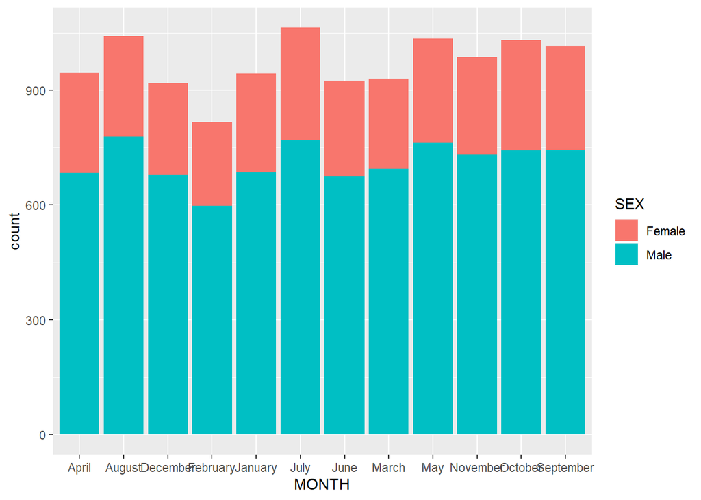

```r
ggplot(c2015,aes(MONTH, fill=SEX))+
geom_bar()
```

#### 10 Implement geom_bar on MONTH and SEX with position=‘dodge’

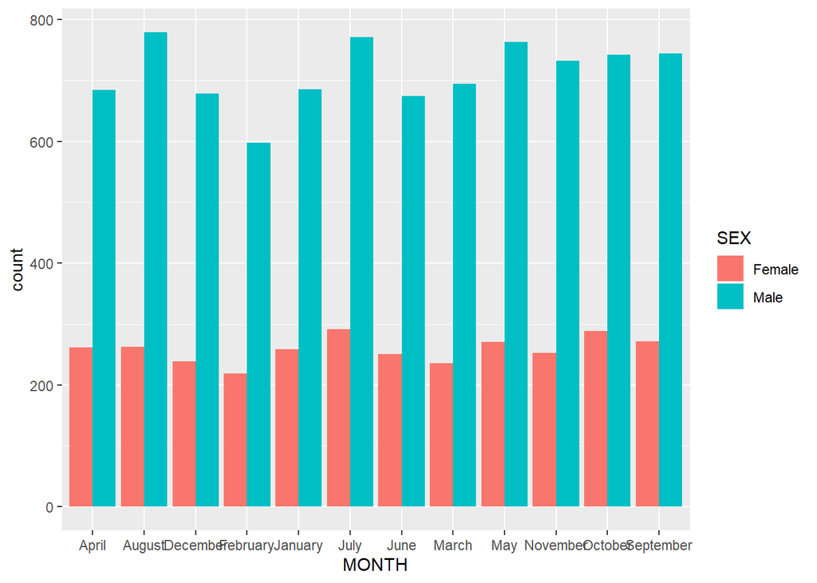

```r
ggplot(c2015,aes(MONTH,fill = SEX))+
  geom_bar(position = 'dodge')
```

#### 11Plot a bar chart of average speeds in months using geom_col

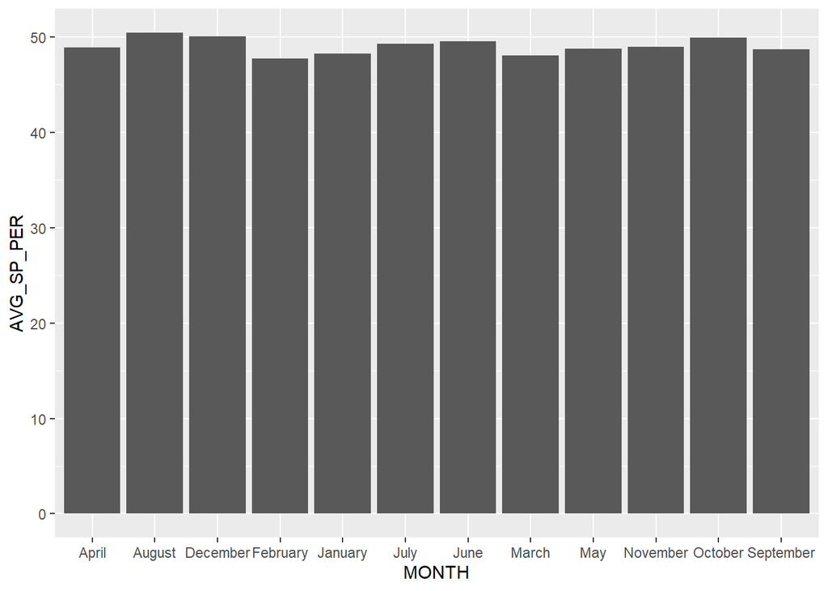

```r
monthdata = c2015%>% group_by(MONTH)%>% mutate(AVG_SP_PER = mean(TRAV_SP)/n())
ggplot(monthdata,aes(MONTH))+
  geom_col(aes(y=AVG_SP_PER))
```

#### 12 Plot a bar chart of average speeds in months using geom_bar

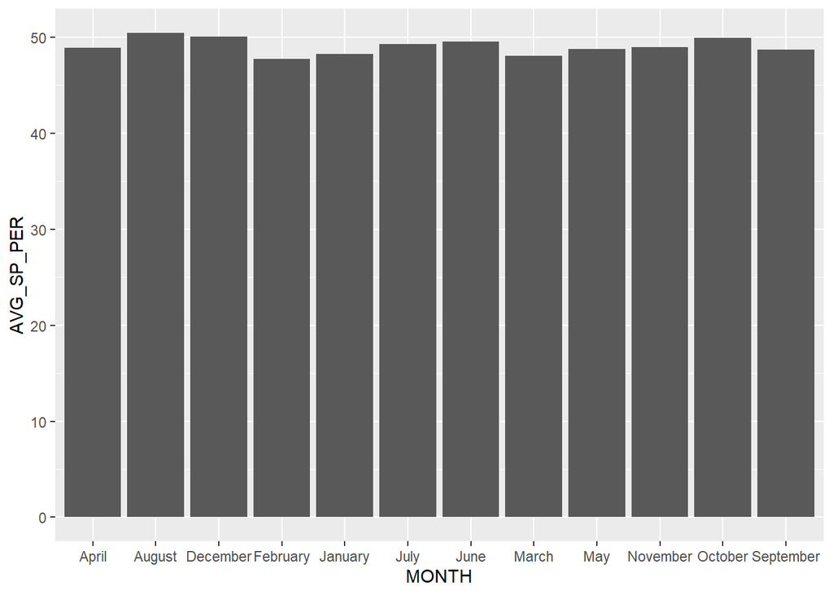

```r
ggplot(monthdata,aes(x=MONTH ))+
geom_bar(aes(y=AVG_SP_PER),stat='identity')
```

#### 13Plot a bar chart of average speeds in months filled by SEX

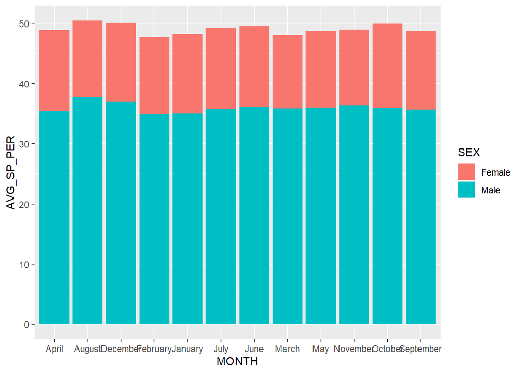

```r
ggplot(monthdata,aes(MONTH, fill=SEX ))+
geom_col(aes(y=AVG_SP_PER))
```

#### 14Plot a bar chart of average speeds in months colored by INJ_SEV

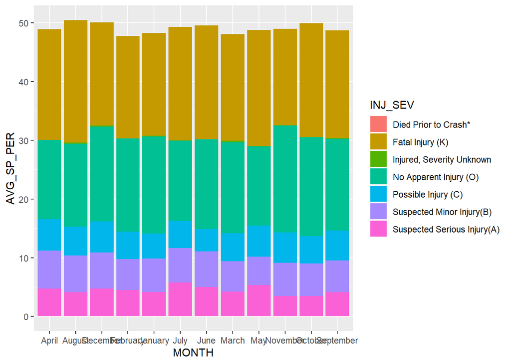

```r
ggplot(monthdata,aes(MONTH,fill=INJ_SEV))+
geom_col(aes(y=AVG_SP_PER))
```

####15Refer to this link to have a similar following plot: Horizontal axis is for (monthly) average speed The vertical axis is for months Color by two colors: one for above overall average speed and the other for below the avarage speedThe speed on the horizontal axis is standardized

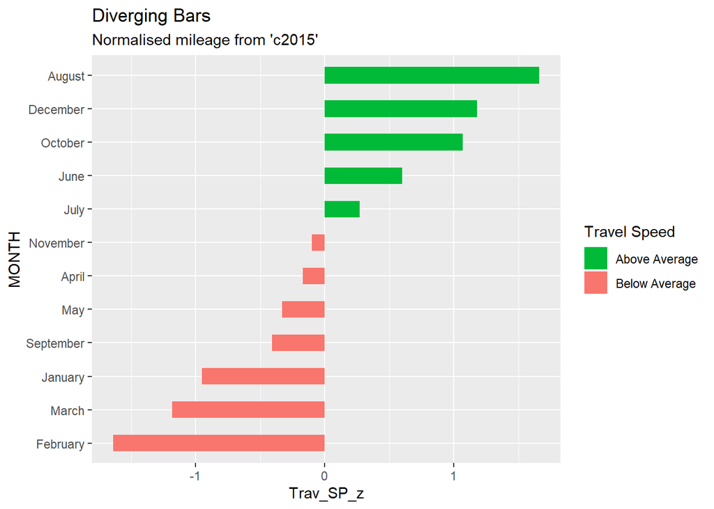

```r
#standarized speed
#create mean speed column, might need that in early problem
#add column for average speed
# Data Prep
Summary = c2015%>% group_by(MONTH)%>% summarise(mean=mean(TRAV_SP))%>% arrange(mean)
Summary$Trav_SP_z = round((Summary$mean-mean(Summary$mean))/sd(Summary$mean),2)
Summary$TRAV_SP_type = ifelse(Summary$Trav_SP_z<0,'below','above')
Summary$MONTH = factor(Summary$MONTH,levels = Summary$MONTH)


# Diverging Barcharts
ggplot(Summary, aes(x=MONTH, y=Trav_SP_z, label = Trav_SP_z)) +   geom_bar(stat='identity', aes(fill=TRAV_SP_type), width=.5)  +
  scale_fill_manual(name="Travel Speed",
                    labels = c("Above Average", "Below Average"),
                    values = c("above"="#00ba38", "below"="#f8766d")) +
  labs(subtitle="Normalised mileage from 'c2015'",
       title= "Diverging Bars") +
  coord_flip()
```

#### 16 Refer to this link to have a similar following plot: Horizontal Axis is for mean speed Vertical Axis is for INJ_SEV Color by SEX The numbers of speed are shown in points.

[figure not shown]

```r
injury = c2015%>% group_by(INJ_SEV,SEX)%>% summarise(mean=mean(TRAV_SP))%>%ungroup()
injury$mean_sp=round(injury$mean,1)

ggplot(injury,aes(x=INJ_SEV,y=mean_sp, label =mean_sp))+ geom_point(stat = 'identity',aes(col=SEX),size=7, alpha=0.7)+
 scale_color_manual(name="Travel speed",
                     labels = c("Male", "Female"),
                     values = c("Male"="#00ba38", "Female"="#f8766d")) +
  geom_text(color="white", size=2) +
  labs(title=" Dot Plot",
       subtitle="Mean Travel Speed from'c2015': Dotplot") +
  ylim(39, 88) +
  coord_flip()
```

#### 17Refer to this link to have a similar following plot: Horizontal Axis is for speed Vertical Axis is for DAY Color by SEX The should be a invisible vertical line seperating the two sexes.

```r
library(ggthemes)
days = c2015%>% group_by(DAY,SEX)%>% summarise(mean=mean(TRAV_SP))%>% arrange(mean)%>%ungroup()
days$MEAN_SP = round(days$mean,2)
days$MEAN_SP[days$SEX=='Male']=-days$MEAN_SP
```

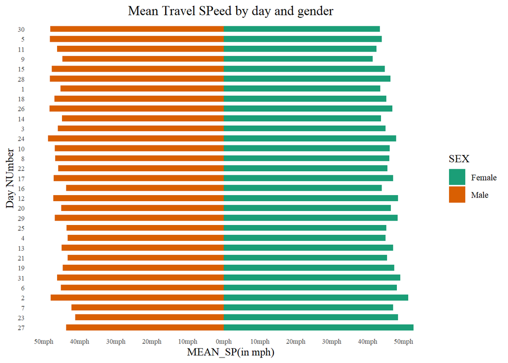

```r
# X Axis Breaks and Labels
brks <- seq(-50, 50, 10)
lbls = paste0(as.character(c(seq(50, 0, -10), seq(10, 50, 10))), "mph")

# Plot
ggplot(days, aes(x = reorder(DAY,-MEAN_SP), y = MEAN_SP, fill = SEX)) +   # Fill column
                              geom_bar(stat = "identity", width = .6) +   # draw the bars
                              scale_y_continuous(breaks = brks,   # Breaks
                                                 labels = lbls) + # Labels
                              coord_flip() +  # Flip axes
                              labs(title="Mean Travel SPeed by day and gender") +
                              theme_tufte() +  # Tufte theme from ggfortify
                              theme(plot.title = element_text(hjust = .5),
                                    axis.ticks = element_blank(),
                                    axis.text = element_text(size = 7)) +   # Centre plot title
                              scale_fill_brewer(palette = "Dark2") +
  xlab('Day NUmber')+
  ylab('MEAN_SP(in mph)')
```

#### 18-20. Generate three other interesting graphs from the dataset.

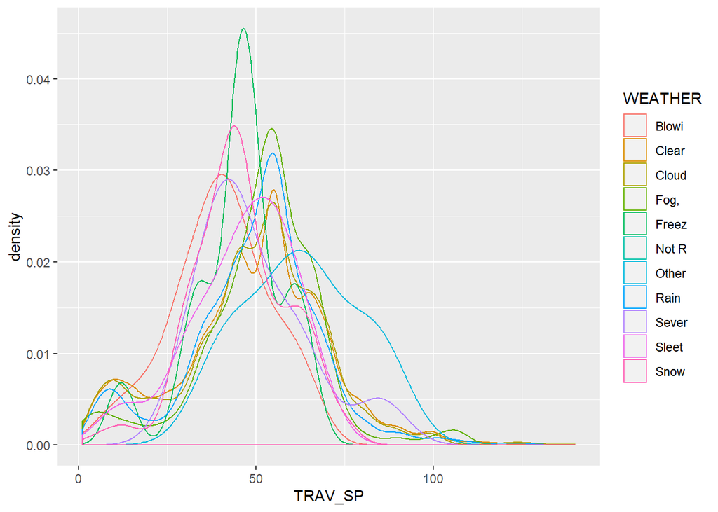

```r
ggplot(c2015,aes(TRAV_SP,color = WEATHER),)+
       geom_density()
```

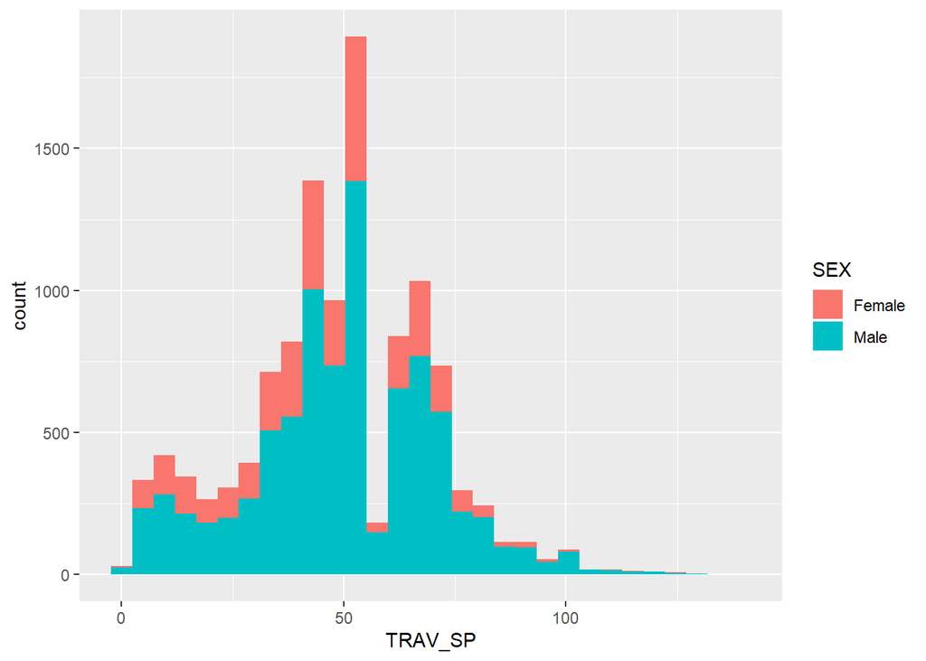

```r
ggplot(c2015,aes(x=TRAV_SP, fill=SEX) )+
  geom_histogram()
```

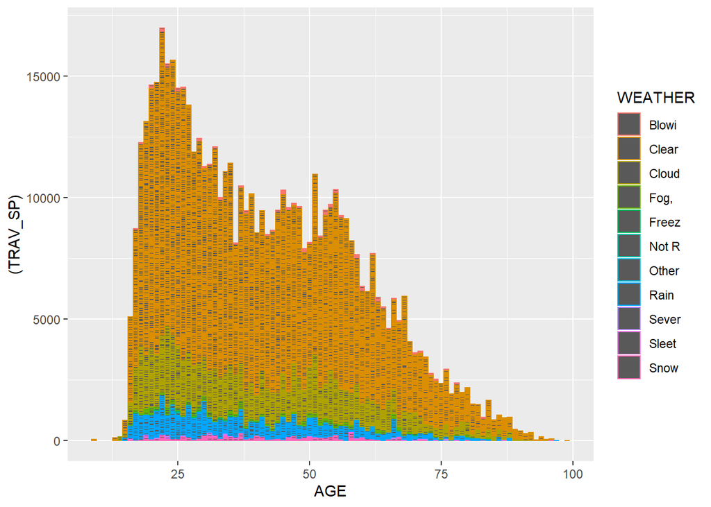

```r
ggplot(c2015,aes(x=AGE,y=(TRAV_SP), color=WEATHER))+
geom_bar(stat='identity')
```